# Essentials of Data Analytics - Jcomp

Chandan Kumar

01/03/2021

# Topic: Rainfall Prediction and its effect on Agriculture

### Reg. No: 18BCE1020

### Name: Chandan Kumar

# Problem Statement and Objectives

### Problem Statement

#### Rainfall prediction is a challenging task because of the dynamic nature of climate phenomena and random fluctuations involved in the physical process. Such a prediction is particularly challenging in Australia where in a long-term analysis the rate of change in the frequency and intensity of rainfall extremes can often be greater than the rate of change for average rainfall.

#### A bad rainfall prediction can affect the agriculture mostly framers as their whole crop is depend on the rainfall and agriculture is always an important part of every economy. So, making an accurate prediction of the rainfall somewhat good. There are number of techniques are used of machine learning but accuracy is always a matter of concern in prediction made in rainfall. There are number of causes made by rainfall affecting the world ex. Drought, Flood and intense summer heat etc. And it will also affect water resources around the world.

### What data have you chosen?(Chosen Dataset, Source of dataset, Description of dataset, basic commands to describe dataset)

#### The Original Source of the datasets are given below:

#### http://www.bom.gov.au/climate/dwo/ , http://www.bom.gov.au/climate/data.

#### The dataset contains has 145460 rows and 23 columns. It has dataset contains both categorical as well as numerical values. It also contains a time period of 10 years of records which can be useful for Time Series model.

#### Along with this, I have used data from http://www.data.guv.au for the agriculture based data

### Objectives

#### 1. The goal of weather prediction is to provide information whether it will rain or not to people and organizations and they can use this to reduce weather-related losses and enhance societal benefits, including protection of life and property, public health and safety, and support of economic prosperity and quality of life.

#### 2. I am also going to visualize various attributes of the dataset and draw insights from it.

#### 3. The other objective is, using time series models, forecast the amount of rainfall.

#### 4. The major objective of this project is to relate rainfall with agriculture and forecast the production based on the meteorological attributes present in the data.

### Scope of the project:

#### This work can be used for the following problems:

#### i)Getting high yield of crops

#### ii)To decide favourable day to conduct outdoor sports events.

#### iii)To decide the operability of flights.

### Algorithms to be used

#### This project has two type of problems: i) time-series based and ii) classification based.So, for both of them we have to use different models and compare them to build the most accurate and suitable model. Therfore for the time series model I am using the fllowing models:

#### i) ARIMA

#### ii)VAR

#### iii)VARMA

#### iv)Holt-Winter’s Seasonal Method

#### For the classification I am using the following models:

#### i)Logistic regressiom

#### ii)Decision Tree

#### iii)KNN algorithm

## Setup

### Libraries

```r
suppressMessages(library(dplyr))
suppressMessages(library(lubridate))
suppressMessages(library(ggplot2))
suppressMessages(library(forecast))
suppressMessages(library(tseries))
suppressMessages(library(vars)) ## VAR
suppressMessages(library(MTS)) ## VARMA
suppressMessages(library(tidyverse))
suppressMessages(library(fpp2))
suppressMessages(library(astsa))
suppressMessages(library(GGally))
suppressMessages(library(caret))
suppressMessages(library(mice))
suppressMessages(library(VIM))
suppressMessages(library(car))
suppressMessages(library(broom))
suppressMessages(library(rpart))
suppressMessages(library(caTools))
suppressMessages(library(rpart.plot))
suppressMessages(library(e1071))
suppressMessages(library(randomForest))
suppressMessages(library(party))
suppressMessages(library(class))
suppressMessages(library(gmodels))
suppressMessages(library(grid))
suppressMessages(library(reshape2))

suppressMessages(library(tmap))
suppressMessages(library(sf))
suppressMessages(library(raster))
suppressMessages(library(spData))
suppressMessages(library(maps))
suppressMessages(library(leaflet))
suppressMessages(library(ggpubr))
```

### Dataset Exploration

#### Reading Dataset

```r
data=read.csv("weatherAUS.csv")
```

#### Structure of the data

```r
str(data)
```

```
## 'data.frame':    145460 obs. of  23 variables:
##  $ Date         : chr  "2008-12-01" "2008-12-02" "2008-12-03" "2008-12-04" ...
##  $ Location     : chr  "Albury" "Albury" "Albury" "Albury" ...
##  $ MinTemp      : num  13.4 7.4 12.9 9.2 17.5 14.6 14.3 7.7 9.7 13.1 ...
##  $ MaxTemp      : num  22.9 25.1 25.7 28 32.3 29.7 25 26.7 31.9 30.1 ...
##  $ Rainfall     : num  0.6 0 0 0 1 0.2 0 0 0 1.4 ...
##  $ Evaporation  : num  NA NA NA NA NA NA NA NA NA NA ...
##  $ Sunshine     : num  NA NA NA NA NA NA NA NA NA NA ...
##  $ WindGustDir  : chr  "W" "WNW" "WSW" "NE" ...
##  $ WindGustSpeed: int  44 44 46 24 41 56 50 35 80 28 ...
##  $ WindDir9am   : chr  "W" "NNW" "W" "SE" ...
##  $ WindDir3pm   : chr  "WNW" "WSW" "WSW" "E" ...
##  $ WindSpeed9am : int  20 4 19 11 7 19 20 6 7 15 ...
##  $ WindSpeed3pm : int  24 22 26 9 20 24 24 17 28 11 ...
##  $ Humidity9am  : int  71 44 38 45 82 55 49 48 42 58 ...
##  $ Humidity3pm  : int  22 25 30 16 33 23 19 19 9 27 ...
##  $ Pressure9am  : num  1008 1011 1008 1018 1011 ...
##  $ Pressure3pm  : num  1007 1008 1009 1013 1006 ...
##  $ Cloud9am     : int  8 NA NA NA 7 NA 1 NA NA NA ...
##  $ Cloud3pm     : int  NA NA 2 NA 8 NA NA NA NA NA ...
##  $ Temp9am      : num  16.9 17.2 21 18.1 17.8 20.6 18.1 16.3 18.3 20.1 ...
##  $ Temp3pm      : num  21.8 24.3 23.2 26.5 29.7 28.9 24.6 25.5 30.2 28.2 ...
##  $ RainToday    : chr  "No" "No" "No" "No" ...
##  $ RainTomorrow : chr  "No" "No" "No" "No" ...
```

#### Rows and Columns in dataset

```r
dim(data)
```

```
## [1] 145460     23
```

#### First 6 elements of data

```r
head(data)
```

```
##         Date Location MinTemp MaxTemp Rainfall Evaporation Sunshine WindGustDir
## 1 2008-12-01   Albury    13.4    22.9      0.6          NA       NA           W
## 2 2008-12-02   Albury     7.4    25.1      0.0          NA       NA         WNW
## 3 2008-12-03   Albury    12.9    25.7      0.0          NA       NA         WSW
## 4 2008-12-04   Albury     9.2    28.0      0.0          NA       NA          NE
## 5 2008-12-05   Albury    17.5    32.3      1.0          NA       NA           W
## 6 2008-12-06   Albury    14.6    29.7      0.2          NA       NA         WNW
##   WindGustSpeed WindDir9am WindDir3pm WindSpeed9am WindSpeed3pm Humidity9am
## 1            44          W        WNW           20           24          71
## 2            44        NNW        WSW            4           22          44
## 3            46          W        WSW           19           26          38
## 4            24         SE          E           11            9          45
## 5            41        ENE         NW            7           20          82
## 6            56          W          W           19           24          55
##   Humidity3pm Pressure9am Pressure3pm Cloud9am Cloud3pm Temp9am Temp3pm
## 1          22      1007.7      1007.1        8       NA    16.9    21.8
## 2          25      1010.6      1007.8       NA       NA    17.2    24.3
## 3          30      1007.6      1008.7       NA        2    21.0    23.2
## 4          16      1017.6      1012.8       NA       NA    18.1    26.5
## 5          33      1010.8      1006.0        7        8    17.8    29.7
## 6          23      1009.2      1005.4       NA       NA    20.6    28.9
##   RainToday RainTomorrow
## 1        No           No
## 2        No           No
## 3        No           No
## 4        No           No
## 5        No           No
## 6        No           No
```

## Data Cleaning

#### Changing ‘Date’ from chr to Date type

```r
data$Date=as.POSIXct(data$Date, format="%Y-%m-%d")
str(data$Date)
```

```
##  POSIXct[1:145460], format: "2008-12-01" "2008-12-02" "2008-12-03" "2008-12-04" "2008-12-05" ...
```

#### Adding day column in the dataset

```r
Day=wday(data$Date, label=T)
data=data%>%
  mutate(Day)

head(data)
```

```
##         Date Location MinTemp MaxTemp Rainfall Evaporation Sunshine WindGustDir
## 1 2008-12-01   Albury    13.4    22.9      0.6          NA       NA           W
## 2 2008-12-02   Albury     7.4    25.1      0.0          NA       NA         WNW
## 3 2008-12-03   Albury    12.9    25.7      0.0          NA       NA         WSW
## 4 2008-12-04   Albury     9.2    28.0      0.0          NA       NA          NE
## 5 2008-12-05   Albury    17.5    32.3      1.0          NA       NA           W
## 6 2008-12-06   Albury    14.6    29.7      0.2          NA       NA         WNW
##   WindGustSpeed WindDir9am WindDir3pm WindSpeed9am WindSpeed3pm Humidity9am
## 1            44          W        WNW           20           24          71
## 2            44        NNW        WSW            4           22          44
## 3            46          W        WSW           19           26          38
## 4            24         SE          E           11            9          45
## 5            41        ENE         NW            7           20          82
## 6            56          W          W           19           24          55
##   Humidity3pm Pressure9am Pressure3pm Cloud9am Cloud3pm Temp9am Temp3pm
## 1          22      1007.7      1007.1        8       NA    16.9    21.8
## 2          25      1010.6      1007.8       NA       NA    17.2    24.3
## 3          30      1007.6      1008.7       NA        2    21.0    23.2
## 4          16      1017.6      1012.8       NA       NA    18.1    26.5
## 5          33      1010.8      1006.0        7        8    17.8    29.7
## 6          23      1009.2      1005.4       NA       NA    20.6    28.9
##   RainToday RainTomorrow Day
## 1        No           No Mon
## 2        No           No Tue
## 3        No           No Wed
## 4        No           No Thu
## 5        No           No Fri
## 6        No           No Sat
```

#### Checking for NA values in ‘Date’ Column

```r
sum(is.na(data$Date))
```

```
## [1] 0
```

#### Checking for any missing value/ repetition of name etc in ‘Location’ column

```r
unique(data$Location)
```

```
##  [1] "Albury"           "BadgerysCreek"    "Cobar"            "CoffsHarbour"
##  [5] "Moree"            "Newcastle"        "NorahHead"        "NorfolkIsland"
##  [9] "Penrith"          "Richmond"         "Sydney"           "SydneyAirport"
## [13] "WaggaWagga"       "Williamtown"      "Wollongong"       "Canberra"
## [17] "Tuggeranong"      "MountGinini"      "Ballarat"         "Bendigo"
## [21] "Sale"             "MelbourneAirport" "Melbourne"        "Mildura"
## [25] "Nhil"             "Portland"         "Watsonia"         "Dartmoor"
## [29] "Brisbane"         "Cairns"           "GoldCoast"        "Townsville"
## [33] "Adelaide"         "MountGambier"     "Nuriootpa"        "Woomera"
## [37] "Albany"           "Witchcliffe"      "PearceRAAF"       "PerthAirport"
## [41] "Perth"            "SalmonGums"       "Walpole"          "Hobart"
## [45] "Launceston"       "AliceSprings"     "Darwin"           "Katherine"
## [49] "Uluru"
```

#### Checking NA values in all other numerical columns.

```r
data%>%
  summarise(m1=sum(is.na(MinTemp)), m2=sum(is.na(MaxTemp)), m3=sum(is.na(Rainfall)), m4=sum(is.na(Evaporation)), m5=sum(is.na(Sunshine)), m6=sum(is.na(WindDir9am)), m7=sum(is.na(WindDir3pm)), m8=sum(is.na(Humidity3pm)), m9=sum(is.na(Humidity3pm)) )
```

```
##     m1   m2   m3    m4    m5    m6   m7   m8   m9
## 1 1485 1261 3261 62790 69835 10566 4228 4507 4507
```

### Visualising number of missing values

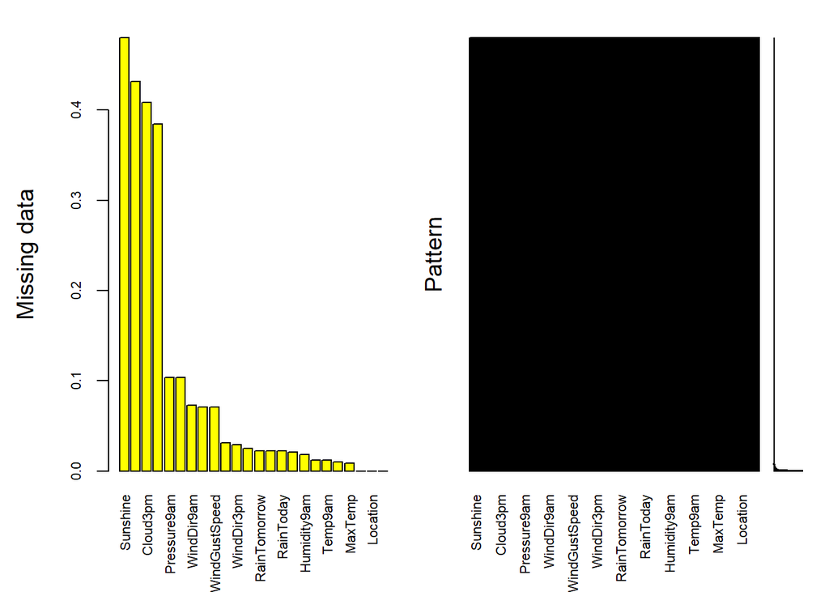

```
##
##  Variables sorted by number of missings:
##       Variable      Count
##       Sunshine 0.48009762
##    Evaporation 0.43166506
##       Cloud3pm 0.40807095
##       Cloud9am 0.38421559
##    Pressure9am 0.10356799
##    Pressure3pm 0.10331363
##     WindDir9am 0.07263853
##    WindGustDir 0.07098859
##  WindGustSpeed 0.07055548
##    Humidity3pm 0.03098446
##     WindDir3pm 0.02906641
##        Temp3pm 0.02481094
##   RainTomorrow 0.02245978
##       Rainfall 0.02241853
##      RainToday 0.02241853
##   WindSpeed3pm 0.02105046
##    Humidity9am 0.01824557
##   WindSpeed9am 0.01214767
##        Temp9am 0.01214767
##        MinTemp 0.01020899
##        MaxTemp 0.00866905
##           Date 0.00000000
##       Location 0.00000000
##            Day 0.00000000
```

```r
mice_plot <- aggr(data, col=c('navyblue','yellow'),
numbers=TRUE, sortVars=TRUE,
labels=names(data), cex.axis=.7,
gap=3, ylab=c("Missing data","Pattern"))
```

#### Removing NA values with appriopriate value.

```r
data=data%>%
  mutate(MinTemp=replace(MinTemp, is.na(MinTemp), mean(MinTemp, na.rm = T)),
         MaxTemp=replace(MaxTemp, is.na(MaxTemp), mean(MaxTemp, na.rm = T)),
         Rainfall=replace(Rainfall, is.na(Rainfall), mean(Rainfall, na.rm = T)),
         Humidity9am=replace(Humidity9am, is.na(Humidity9am), mean(Humidity9am, na.rm = T)),
         Humidity3pm=replace(Humidity3pm, is.na(Humidity3pm), mean(Humidity3pm, na.rm = T)),
         WindGustSpeed=replace(WindGustSpeed, is.na(WindGustSpeed), mean(WindGustSpeed, na.rm = T)),
         Sunshine=replace(Sunshine, is.na(Sunshine), mean(Sunshine, na.rm = T)),
         Cloud3pm=replace(Cloud3pm, is.na(Cloud3pm), mean(Cloud3pm, na.rm = T)),
         Evaporation=replace(Evaporation, is.na(Evaporation), mean(Evaporation, na.rm = T)),
         Cloud9am=replace(Cloud9am, is.na(Cloud9am), mean(Cloud9am, na.rm = T)),
         Pressure9am=replace(Pressure9am, is.na(Pressure9am), mean(Pressure9am, na.rm = T)),
         Pressure3pm=replace(Pressure3pm, is.na(Pressure3pm), mean(Pressure3pm, na.rm = T)),
         Temp3pm=replace(Temp3pm, is.na(Temp3pm), mean(Temp3pm, na.rm = T)),
         WindSpeed9am=replace(WindSpeed9am, is.na(WindSpeed9am), mean(WindSpeed9am, na.rm = T)),
         WindSpeed3pm=replace(WindSpeed3pm, is.na(WindSpeed3pm), mean(WindSpeed3pm, na.rm = T)),
         Temp9am=replace(Temp9am, is.na(Temp9am), mean(Temp9am, na.rm = T))
         )
```

### Visualising after cleaning

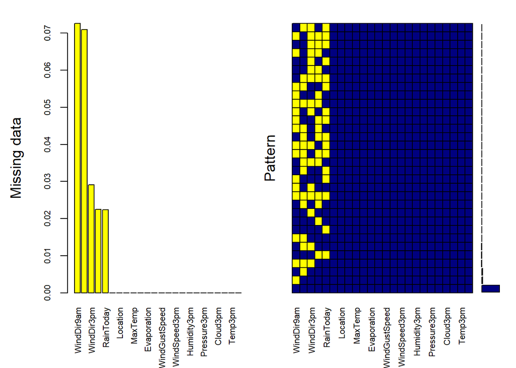

```
##
##  Variables sorted by number of missings:
##       Variable      Count
##     WindDir9am 0.07263853
##    WindGustDir 0.07098859
##     WindDir3pm 0.02906641
##   RainTomorrow 0.02245978
##      RainToday 0.02241853
##           Date 0.00000000
##       Location 0.00000000
##        MinTemp 0.00000000
##        MaxTemp 0.00000000
##       Rainfall 0.00000000
##    Evaporation 0.00000000
##       Sunshine 0.00000000
##  WindGustSpeed 0.00000000
##   WindSpeed9am 0.00000000
##   WindSpeed3pm 0.00000000
##    Humidity9am 0.00000000
##    Humidity3pm 0.00000000
##    Pressure9am 0.00000000
##    Pressure3pm 0.00000000
##       Cloud9am 0.00000000
##       Cloud3pm 0.00000000
##        Temp9am 0.00000000
##        Temp3pm 0.00000000
##            Day 0.00000000
```

```r
mice_plot <- aggr(data, col=c('navyblue','yellow'),
numbers=TRUE, sortVars=TRUE,
labels=names(data), cex.axis=.7,
gap=3, ylab=c("Missing data","Pattern"))
```

#### Making Rain or Not Rained as factor from chr

```r
data$RainToday=factor(data$RainToday, labels = c(0,1))
str(data$RainToday)
```

```
##  Factor w/ 2 levels "0","1": 1 1 1 1 1 1 1 1 1 2 ...
```

```r
data$RainTomorrow=factor(data$RainTomorrow, labels = c(0,1))
str(data$RainTomorrow)
```

```
##  Factor w/ 2 levels "0","1": 1 1 1 1 1 1 1 1 2 1 ...
```

# EDA

### Statistical Analysis

#### Min Temprature

```r
mean(data$MinTemp)
```

```
## [1] 12.19403
```

#### The average minimum temprature of dataset is 12.19

```r
range(data$MinTemp)
```

```
## [1] -8.5 33.9
```

#### The range of MinTemp is from -8.5 to 33.9

```r
quantile(data$MinTemp)
```

```
##   0%  25%  50%  75% 100%
## -8.5  7.7 12.1 16.8 33.9
```

#### From here we can observe that the median of the minTemp is 12.1

```r
sd(data$MinTemp)
```

```
## [1] 6.36575
```

#### The standard deviation of minTemp is 6.36

#### MaxTemp

```r
mean(data$MaxTemp)
```

```
## [1] 23.22135
```

#### The mean of MaxTemp is 23.22

```r
quantile(data$MaxTemp)
```

```
##   0%  25%  50%  75% 100%
## -4.8 18.0 22.7 28.2 48.1
```

```r
sd(data$MaxTemp)
```

```
## [1] 7.088124
```

#### The standard deviation of MaxTemp is 7.088

#### RainFall

```r
mean(data$Rainfall)
```

```
## [1] 2.360918
```

#### The average rainfall is 2.36 mm

```r
quantile(data$Rainfall)
```

```
##   0%  25%  50%  75% 100%
##    0    0    0    1  371
```

#### Here we can see that Rainfall ranges between 0 to 371 mm

```r
sd(data$Rainfall)
```

```
## [1] 8.382488
```

#### The standard deviation of Rainfall is 8.38

#### WindGust Dir

```r
table(data$WindGustDir)
```

```
##
##    E  ENE  ESE    N   NE  NNE  NNW   NW    S   SE  SSE  SSW   SW    W  WNW  WSW
## 9181 8104 7372 9313 7133 6548 6620 8122 9168 9418 9216 8736 8967 9915 8252 9069
```

#### Here we can observe that the maximum number of wind directon is towards West.

### Visualisation

#### Maximum and Minimum Temp Comaprison of different Location

```r
TempbyLoc=data%>%
  group_by(Location)%>%
  summarise(minTemp=min(MinTemp), maxTemp=max(MaxTemp), avgRain=mean(Rainfall))
```

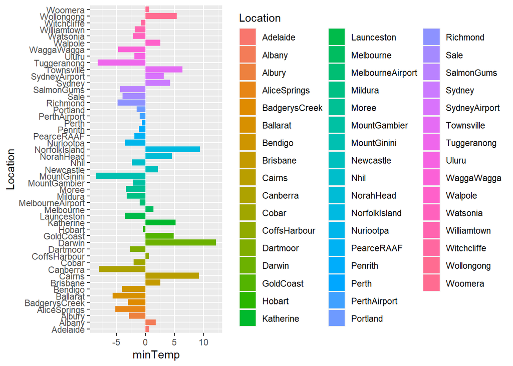

```r
ggplot(data=TempbyLoc, aes(x=Location, y=minTemp, fill=Location)) + geom_bar(stat = 'identity') + coord_flip()
```

#### From the above bargraph we can observe that MountGinini has recorded the minimum temprature in the span of these 10 years.

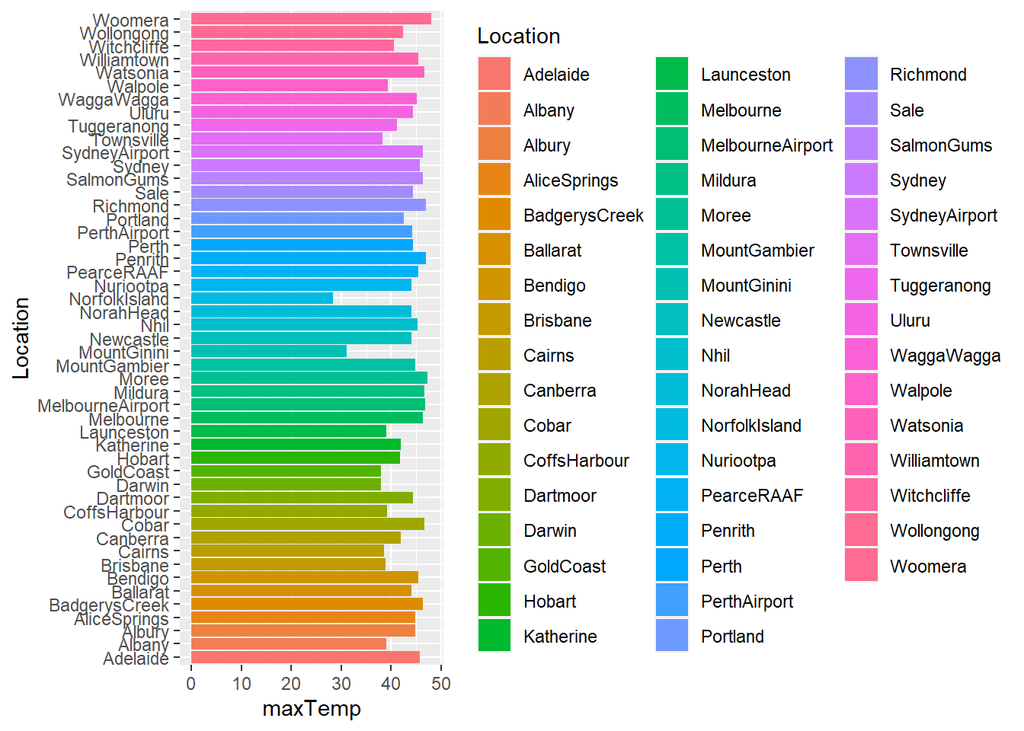

```r
ggplot(data=TempbyLoc, aes(x=Location, y=maxTemp, fill=Location)) + geom_bar(stat = 'identity') + coord_flip()
```

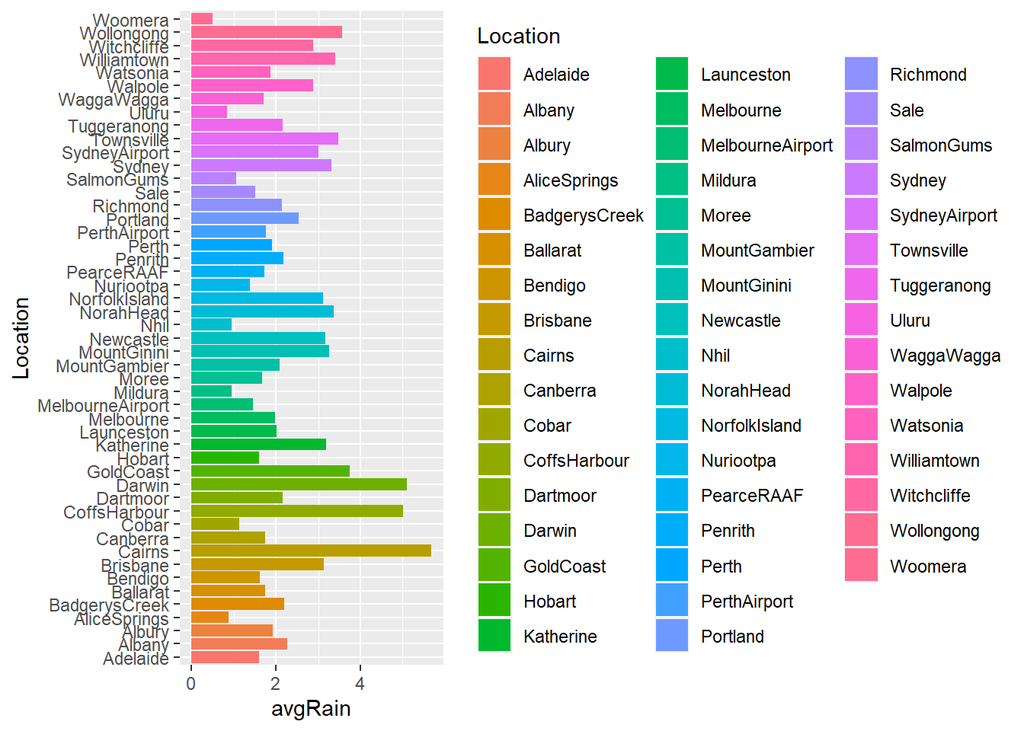

```r
ggplot(data=TempbyLoc, aes(x=Location, y=avgRain, fill=Location)) + geom_bar(stat = 'identity') + coord_flip()
```

#### In the above we can observe that Cairns has recorded the maximum average rainfall in the span of these 10 years.

### Average Rain Every Year / Month

#### Year-wise

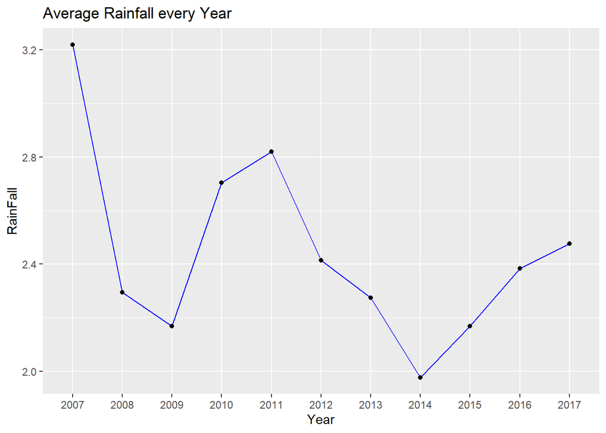

```r
data%>%
  mutate(year=format(Date,"%Y"))%>%
  group_by(year)%>%
  summarise(rain=mean(Rainfall))%>%
  ggplot(aes(x=year, y=rain, group=1))+geom_line(color="blue")+geom_point()+labs(title="Average Rainfall every Year", x="Year", y="RainFall")
```

#### In the above line graph we can observe that Maximum avg rainfall is observed in 2007 and least in 2014.

#### Month Wise

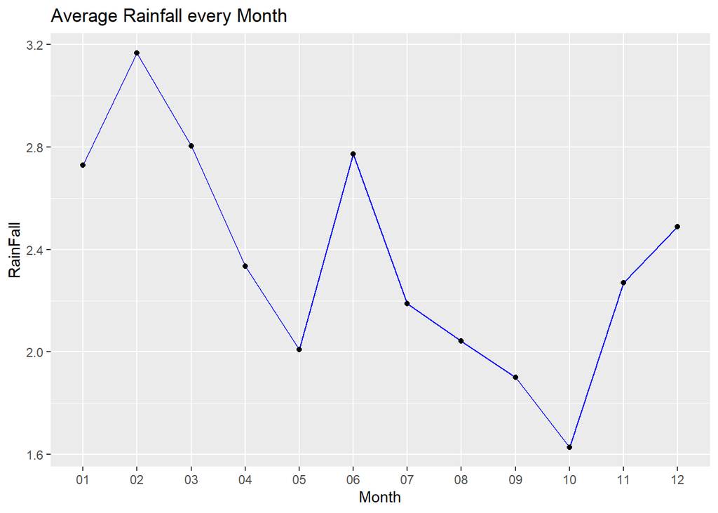

```r
data%>%
  mutate(month=format(Date,"%m"))%>%
  group_by(month)%>%
  summarise(rain=mean(Rainfall))%>%
  ggplot(aes(x=month, y=rain, group=1))+geom_line(color="blue")+geom_point()+labs(title="Average Rainfall every Month", x="Month", y="RainFall")
```

#### In the above line graph we can observe that maximum Rainfall has occurred in the month of February and the least is in October.

# Time Series Analysis

#### Model used:

#### 1. ARIMA(Auto Regression Integrated Moving Average)

#### 2. VAR(Vector Auto Regression)

#### 3. VARMA(Vector Autoregression Moving Average)

#### 4. Holt-Winter’s Seasonal Method

### Splitting Date into year, month and date

```r
year <- as.numeric(format(data$Date,"%Y"))
mon <- as.numeric(format(data$Date,"%m"))
day <- as.numeric(format(data$Date,"%d"))
```

### Combining old data with new formed columns

```r
split_data=cbind(data,year,mon,day)
str(split_data)
```

```
## 'data.frame':    145460 obs. of  27 variables:
##  $ Date         : POSIXct, format: "2008-12-01" "2008-12-02" ...
##  $ Location     : chr  "Albury" "Albury" "Albury" "Albury" ...
##  $ MinTemp      : num  13.4 7.4 12.9 9.2 17.5 14.6 14.3 7.7 9.7 13.1 ...
##  $ MaxTemp      : num  22.9 25.1 25.7 28 32.3 29.7 25 26.7 31.9 30.1 ...
##  $ Rainfall     : num  0.6 0 0 0 1 0.2 0 0 0 1.4 ...
##  $ Evaporation  : num  5.47 5.47 5.47 5.47 5.47 ...
##  $ Sunshine     : num  7.61 7.61 7.61 7.61 7.61 ...
##  $ WindGustDir  : chr  "W" "WNW" "WSW" "NE" ...
##  $ WindGustSpeed: num  44 44 46 24 41 56 50 35 80 28 ...
##  $ WindDir9am   : chr  "W" "NNW" "W" "SE" ...
##  $ WindDir3pm   : chr  "WNW" "WSW" "WSW" "E" ...
##  $ WindSpeed9am : num  20 4 19 11 7 19 20 6 7 15 ...
##  $ WindSpeed3pm : num  24 22 26 9 20 24 24 17 28 11 ...
##  $ Humidity9am  : num  71 44 38 45 82 55 49 48 42 58 ...
##  $ Humidity3pm  : num  22 25 30 16 33 23 19 19 9 27 ...
##  $ Pressure9am  : num  1008 1011 1008 1018 1011 ...
##  $ Pressure3pm  : num  1007 1008 1009 1013 1006 ...
##  $ Cloud9am     : num  8 4.45 4.45 4.45 7 ...
##  $ Cloud3pm     : num  4.51 4.51 2 4.51 8 ...
##  $ Temp9am      : num  16.9 17.2 21 18.1 17.8 20.6 18.1 16.3 18.3 20.1 ...
##  $ Temp3pm      : num  21.8 24.3 23.2 26.5 29.7 28.9 24.6 25.5 30.2 28.2 ...
##  $ RainToday    : Factor w/ 2 levels "0","1": 1 1 1 1 1 1 1 1 1 2 ...
##  $ RainTomorrow : Factor w/ 2 levels "0","1": 1 1 1 1 1 1 1 1 2 1 ...
##  $ Day          : Ord.factor w/ 7 levels "Sun"<"Mon"<"Tue"<..: 2 3 4 5 6 7 1 2 3 4 ...
##  $ year         : num  2008 2008 2008 2008 2008 ...
##  $ mon          : num  12 12 12 12 12 12 12 12 12 12 ...
##  $ day          : num  1 2 3 4 5 6 7 8 9 10 ...
```

### Assigning the start and end as well as the cycle of time series data

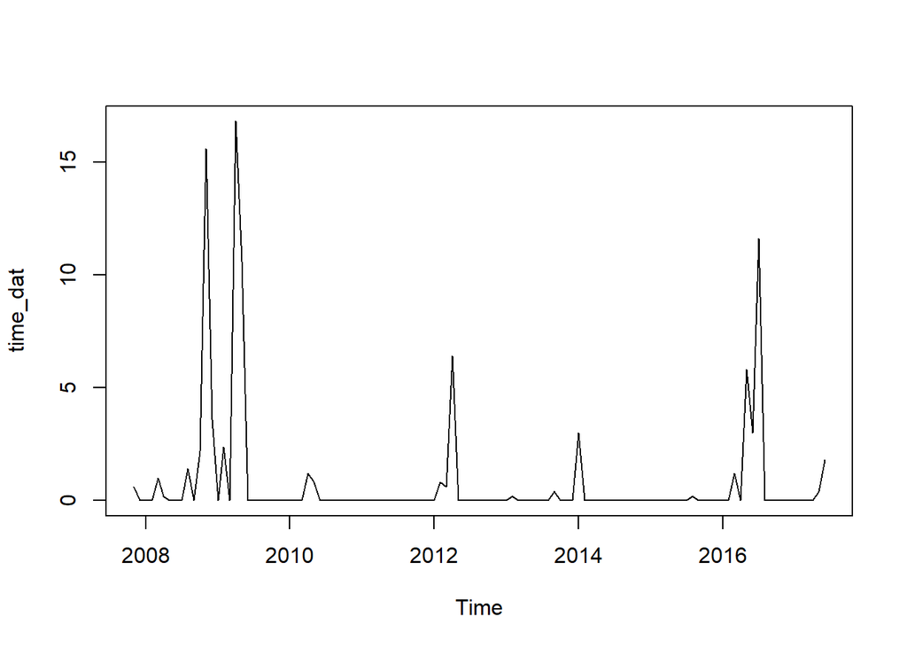

```r
time_dat <- ts(data$Rainfall,start=c(2007,11,01),end=c(2017,06,25),frequency = 12)
plot(time_dat)
```

#### In the above plot we can observe that data does not have any trend, i.e the data is stationary.Therefore to use the data for time series model, we don’t need to differentiate(d=0).

### Data in each cycle

```r
cycle(time_dat)
```

```
##      Jan Feb Mar Apr May Jun Jul Aug Sep Oct Nov Dec
## 2007                                          11  12
## 2008   1   2   3   4   5   6   7   8   9  10  11  12
## 2009   1   2   3   4   5   6   7   8   9  10  11  12
## 2010   1   2   3   4   5   6   7   8   9  10  11  12
## 2011   1   2   3   4   5   6   7   8   9  10  11  12
## 2012   1   2   3   4   5   6   7   8   9  10  11  12
## 2013   1   2   3   4   5   6   7   8   9  10  11  12
## 2014   1   2   3   4   5   6   7   8   9  10  11  12
## 2015   1   2   3   4   5   6   7   8   9  10  11  12
## 2016   1   2   3   4   5   6   7   8   9  10  11  12
## 2017   1   2   3   4   5   6
```

### Plot for each cycle

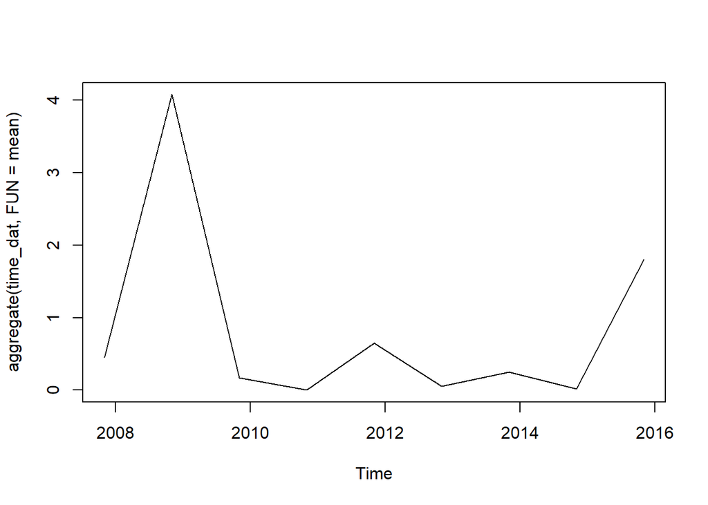

```r
plot(aggregate(time_dat,FUN=mean))
```

### Box Plot of each cycle

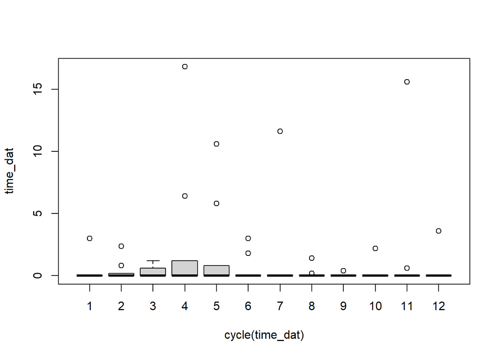

```r
boxplot(time_dat~cycle(time_dat))
```

### Visualising Decomposition

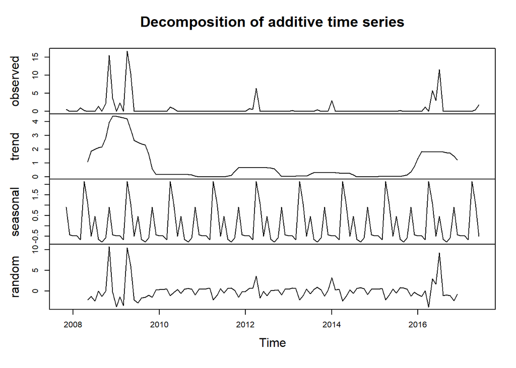

```r
plot(decompose(time_dat))
```

#### The above plot shows that the data has only seasonal trend.

### Making the data stationary

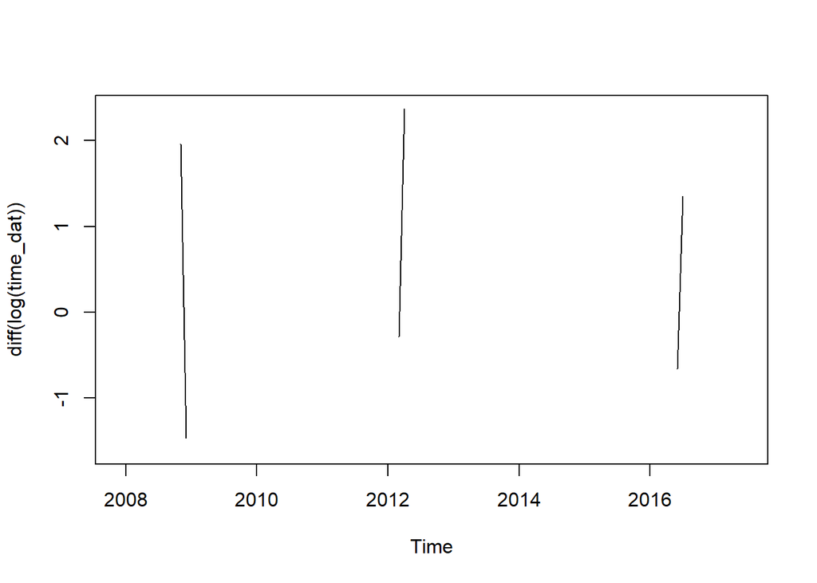

```r
plot(diff(log(time_dat)))
```

#### Although, the data is stationary, still if we still try to differentiate it, the data won’t be able make any sense, making it un-useful.

### Auto correlation of data when it was not made stationary.

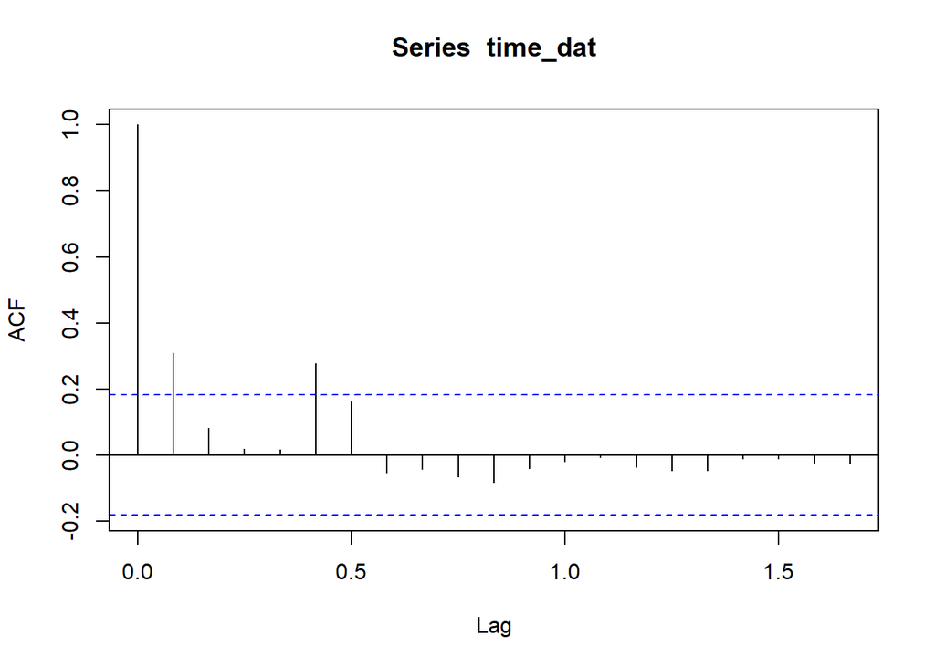

```r
acf(time_dat)
```

## 1.ARIMA

### Model Building using ARIMA

```r
model1 <-auto.arima(time_dat)
model1
```

```
## Series: time_dat
## ARIMA(1,0,0) with non-zero mean
##
## Coefficients:
##          ar1    mean
##       0.3067  0.7941
## s.e.  0.0879  0.3389
##
## sigma^2 estimated as 6.564:  log likelihood=-272.77
## AIC=551.55   AICc=551.76   BIC=559.81
```

#### In the above result, we can observe that ARIMA model gives optimum result for (p,q,d)=(1,0,0). The AIC abd BIC values are 551.55 and 559.81 respectively.

#### AIC and BIC are both penalized-likelihood criteria. AIC is an estimate of a constant plus the relative distance between the unknown true likelihood function of the data and the fitted likelihood function of the model, so that a lower AIC means a model is considered to be closer to the truth. BIC is an estimate of a function of the posterior probability of a model being true, under a certain Bayesian setup, so that a lower BIC means that a model is considered to be more likely to be the true model.

### Residuls Plot

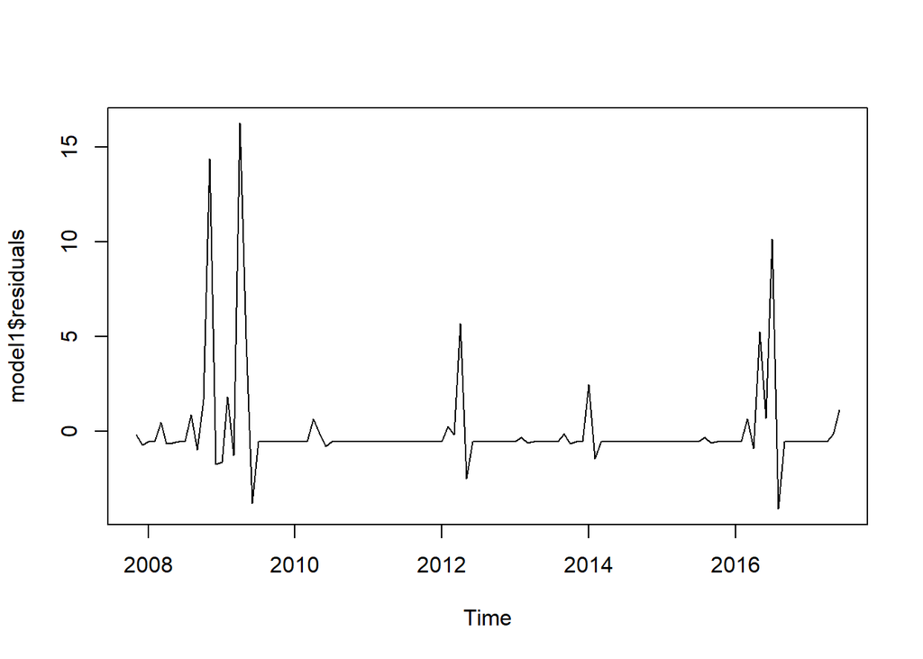

```r
plot.ts(model1$residuals)
```

#### The “residuals” in a time series model are what is left over after fitting a model. For many (but not all) time series models, the residuals are equal to the difference between the observations and the corresponding fitted values.Residuals are useful in checking whether a model has adequately captured the information in the data.

### q-value

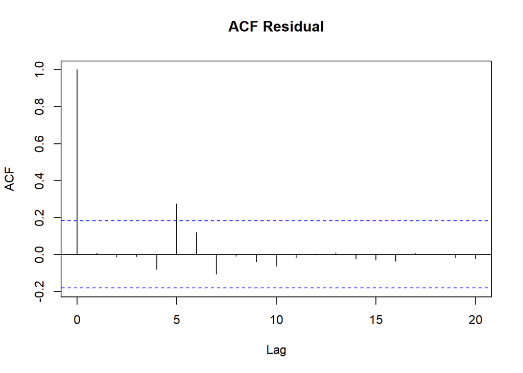

```r
acf(ts(model1$residuals),main="ACF Residual")
```

#### Starting from first line (count it as 0), the line preceding the first inverted line is the value needed. Here, we can see that q=1.

### p-val

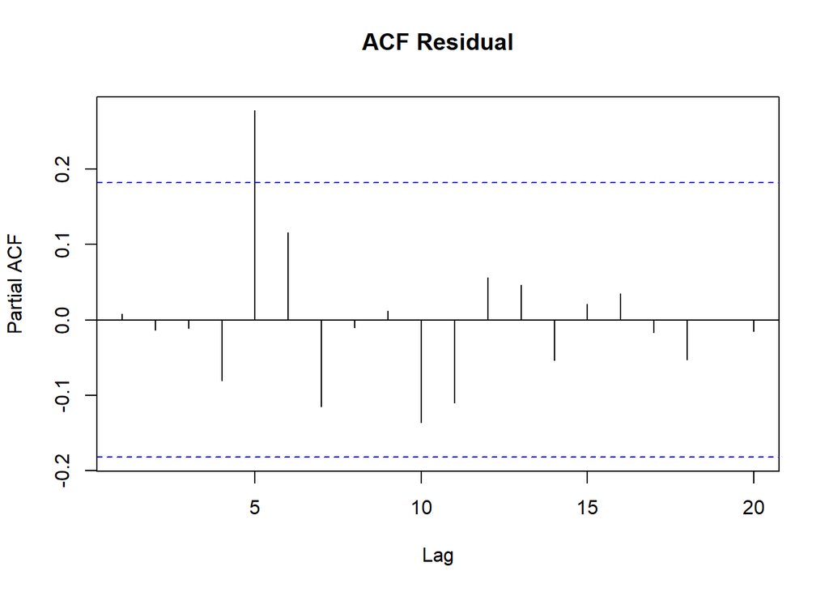

```r
pacf(ts(model1$residuals),main="ACF Residual")
```

#### Similar to acf, here p=0.

### Forecasting values

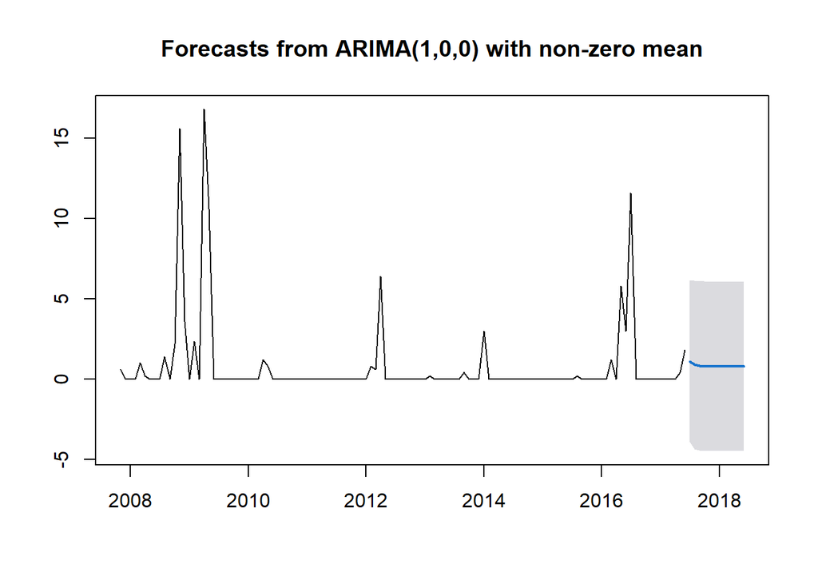

```r
forect <- forecast(model1,level=c(95),h=1*12)
plot(forect)
```

### Summary of ARIMA model

```r
summary(model1)
```

```
## Series: time_dat
## ARIMA(1,0,0) with non-zero mean
##
## Coefficients:
##          ar1    mean
##       0.3067  0.7941
## s.e.  0.0879  0.3389
##
## sigma^2 estimated as 6.564:  log likelihood=-272.77
## AIC=551.55   AICc=551.76   BIC=559.81
##
## Training set error measures:
##                        ME     RMSE      MAE  MPE MAPE      MASE       ACF1
## Training set 0.0006047933 2.539933 1.156613 -Inf  Inf 0.7814859 0.00766371
```

### Plotting the characteristic roots

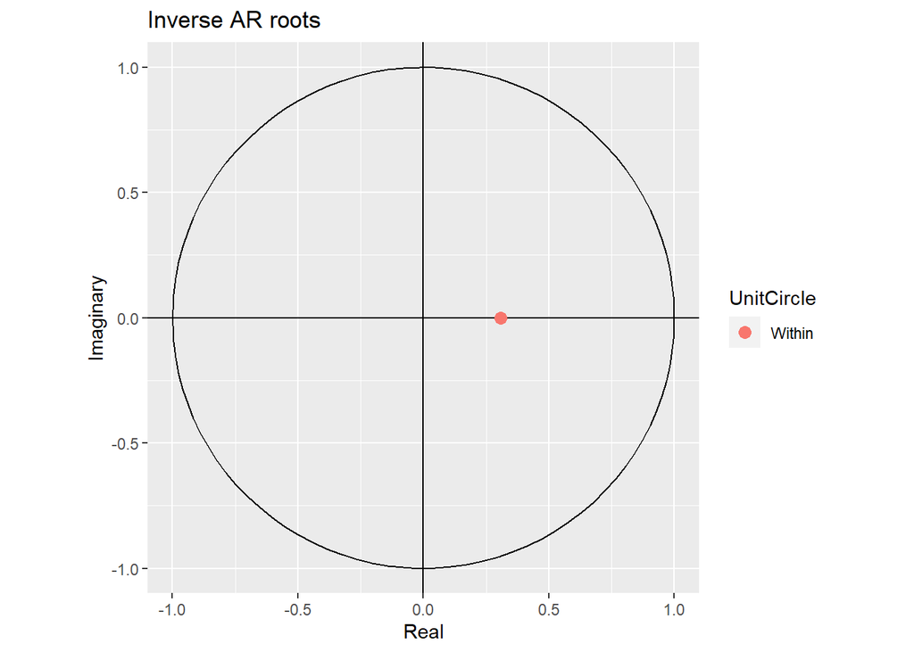

```r
autoplot(model1)
```

#### The red dot in the plot correspond to the root of the polynomial of ARIMA model. It is inside the unit circle, as we would expect because R ensures the fitted model is both stationary and invertible. Any roots close to the unit circle may be numerically unstable, and the corresponding model will not be good for forecasting.

### ACF, PACF plot

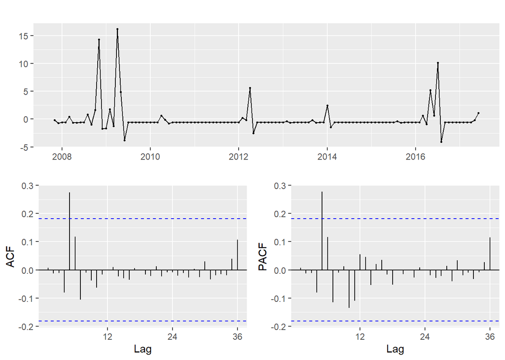

```r
ggtsdisplay(model1$residuals)
```

## 2.Vector Autoregression Model(VAR)

#### One limitation of the ARIMA model is that they impose a unidirectional relationship — the forecast variable is influenced by the predictor variables, but not vice versa. However, there are many cases where the reverse should also be allowed for — where all variables affect each other.

### Selecting rows for forecasting.

```r
temp=data[, c("Pressure3pm", "Rainfall")]
ts_data_vars=ts(temp, start=c(2007,11,01),end=c(2017,06,25),frequency = 12)
```

### Plotting graph for Pressure and Rainfall

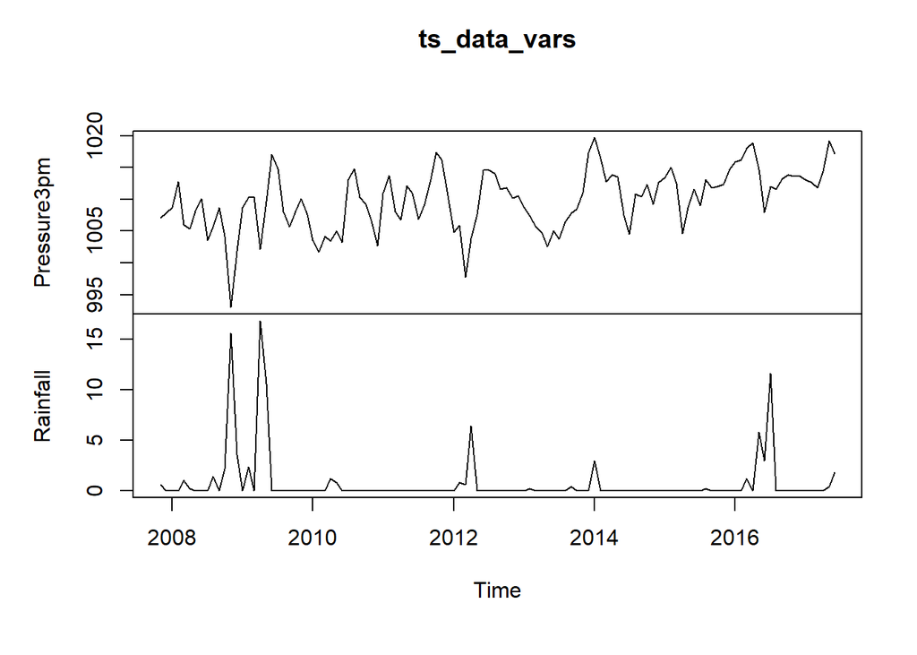

```r
plot.ts(ts_data_vars)
```

### Model building

```r
model2=vars::VAR(ts_data_vars, type = "none", lag.max = 5, ic = "AIC")
summary(model2)
```

```
##
## VAR Estimation Results:
## =========================
## Endogenous variables: Pressure3pm, Rainfall
## Deterministic variables: none
## Sample size: 113
## Log Likelihood: -563.994
## Roots of the characteristic polynomial:
##     1 0.5886 0.5886 0.4332 0.3399 0.1201
## Call:
## vars::VAR(y = ts_data_vars, type = "none", lag.max = 5, ic = "AIC")
##
##
## Estimation results for equation Pressure3pm:
## ============================================
## Pressure3pm = Pressure3pm.l1 + Rainfall.l1 + Pressure3pm.l2 + Rainfall.l2 + Pressure3pm.l3 + Rainfall.l3
##
##                Estimate Std. Error t value Pr(>|t|)
## Pressure3pm.l1  0.97181    0.09609  10.114  < 2e-16 ***
## Rainfall.l1     0.20782    0.14290   1.454  0.14881
## Pressure3pm.l2 -0.24269    0.13155  -1.845  0.06783 .
## Rainfall.l2     0.24756    0.14794   1.673  0.09718 .
## Pressure3pm.l3  0.27064    0.09814   2.758  0.00685 **
## Rainfall.l3    -0.02985    0.14538  -0.205  0.83769
## ---
## Signif. codes:  0 '***' 0.001 '**' 0.01 '*' 0.05 '.' 0.1 ' ' 1
##
##
## Residual standard error: 3.668 on 107 degrees of freedom
## Multiple R-Squared:     1,   Adjusted R-squared:     1
## F-statistic: 1.428e+06 on 6 and 107 DF,  p-value: < 2.2e-16
##
##
## Estimation results for equation Rainfall:
## =========================================
## Rainfall = Pressure3pm.l1 + Rainfall.l1 + Pressure3pm.l2 + Rainfall.l2 + Pressure3pm.l3 + Rainfall.l3
##
##                Estimate Std. Error t value Pr(>|t|)
## Pressure3pm.l1 -0.15487    0.06679  -2.319  0.02232 *
## Rainfall.l1     0.28984    0.09934   2.918  0.00430 **
```

[output cut: 8 more lines]

```
## Residual standard error: 2.55 on 107 degrees of freedom
## Multiple R-Squared: 0.2268,  Adjusted R-squared: 0.1834
## F-statistic:  5.23 on 6 and 107 DF,  p-value: 9.324e-05
##
##
##
## Covariance matrix of residuals:
##             Pressure3pm Rainfall
## Pressure3pm      13.455   -2.178
## Rainfall         -2.178    6.501
##
## Correlation matrix of residuals:
##             Pressure3pm Rainfall
## Pressure3pm      1.0000  -0.2329
## Rainfall        -0.2329   1.0000
```

### Impulse

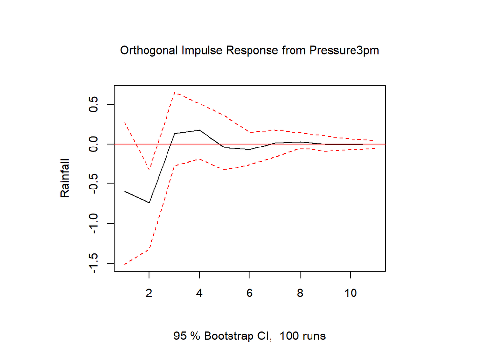

```r
ir.1 <- vars::irf(model2, impulse = "Pressure3pm", response = "Rainfall")
plot(ir.1)
```

### Forecasting and plotting

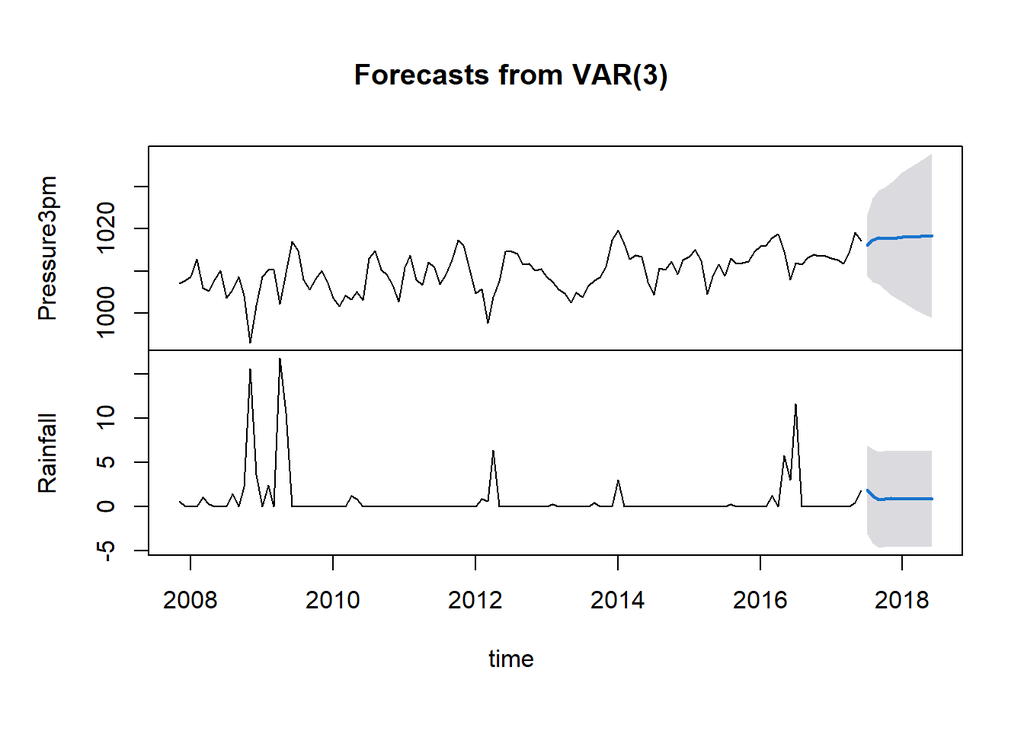

```r
forect2 <- forecast(model2,level=c(95),h=1*12)
plot(forect2)
```

## 3.Vector Autoregression Moving-Average(VARMA)

#### It is the combination of VAR and VMA and a generalized version of ARMA model for multivariate stationary time series. It is characterized by ‘p’ and ‘q’ parameters. Much like, ARMA is capable of acting like an AR model by setting ‘q’ parameter as 0 and as a MA model by setting ‘p’ parameter as 0, VARMA is also capable of acting like an VAR model by setting ‘q’ parameter as 0 and as a VMA model by setting ‘p’ parameter as 0.

#### Reasons to use VARMA model

#### a. More parsimonious representation

#### b. Closed with respect to linear transformations

### Getting optimum value of p&q

```r
Eccm(ts_data_vars)
```

```
## p-values table of Extended Cross-correlation Matrices:
## Column: MA order
## Row   : AR order
##        0      1      2      3      4      5      6
## 0 0.0000 0.0011 0.0777 0.1628 0.1591 0.5859 0.7096
## 1 0.0270 0.4774 0.0308 0.0001 0.0926 0.6089 0.7414
## 2 0.2878 0.2043 0.0627 0.0965 0.2134 0.9882 0.9827
## 3 0.6035 0.3002 0.5606 0.7125 0.0771 0.9957 0.9806
## 4 0.6757 0.3363 0.6363 0.9734 0.9756 0.9967 0.9960
## 5 0.9821 0.7236 0.9999 1.0000 0.9936 0.9994 0.9796
```

### Model building

```r
model3=VARMA(ts_data_vars, p = 5, q = 3, include.mean = T,
    fixed = NULL, beta=NULL, sebeta=NULL,
    prelim = F, details = F, thres = 2)
```

```
## Number of parameters:  34
## initial estimates:  586.2207 -182.7506 0.8409 0.4806 -0.3884 -0.1728 -0.4164 -0.844 0.46 0.4104 -0.0762 -0.0666 0.0172 0.5079 0.4478 -0.1235 -0.1444 0.0082 -0.1235 -0.2634 -0.0156 0.2823 0.0103 -0.393 0.2224 0.2713 0.5681 0.9935 -0.175 -0.2184 -0.3033 0.1378 -0.2937 -0.0954
## Par. lower-bounds:  -208.995 -774.9978 -0.4855 -0.7635 -1.9455 -1.2657 -1.9423 -1.996 -0.5056 -0.1381 -0.3714 -0.4271 -0.9706 -0.4187 -0.7119 -0.9375 -1.2809 -0.8498 -0.8426 -0.6719 -0.2354 0.0138 -1.3213 -1.6807 -0.9582 -0.7919 -0.5919 -0.0387 -1.1667 -1.1774 -1.1826 -0.6541 -1.1576 -0.8641
## Par. upper-bounds:  1381.436 409.4966 2.1673 1.7247 1.1687 0.9202 1.1094 0.3081 1.4256 0.9589 0.2189 0.2939 1.005 1.4345 1.6074 0.6905 0.992 0.8662 0.5956 0.1451 0.2042 0.5508 1.3418 0.8947 1.403 1.3346 1.7281 2.0256 0.8167 0.7406 0.576 0.9296 0.5702 0.6734
## Final   Estimates:  586.2183 -182.7368 1.029617 0.7469378 -0.54771 0.4150632 -0.2827258 -0.8378011 0.3221991 0.3551141 -0.1023227 0.001375735 -0.03304645 0.268216 0.0799465 -0.2898158 0.2411821 0.2620909 -0.1906335 -0.1081953 0.08409138 0.1615289 -0.1599564 -0.5800502 0.3387257 -0.4093063 0.76506…
```

```
##
## Coefficient(s):
##               Estimate  Std. Error  t value Pr(>|t|)
## Pressure3pm  5.862e+02   2.801e+01   20.933  < 2e-16 ***
## Rainfall    -1.827e+02   9.159e+00  -19.951  < 2e-16 ***
## Pressure3pm  1.030e+00          NA       NA       NA
## Rainfall     7.469e-01          NA       NA       NA
## Pressure3pm -5.477e-01          NA       NA       NA
## Rainfall     4.151e-01          NA       NA       NA
## Pressure3pm -2.827e-01          NA       NA       NA
## Rainfall    -8.378e-01          NA       NA       NA
## Pressure3pm  3.222e-01   1.525e-01    2.112  0.03465 *
## Rainfall     3.551e-01   3.110e-01    1.142  0.25353
## Pressure3pm -1.023e-01   8.081e-02   -1.266  0.20543
## Rainfall     1.376e-03   1.125e-01    0.012  0.99025
## Pressure3pm -3.305e-02          NA       NA       NA
## Rainfall     2.682e-01   2.471e-01    1.085  0.27779
## Pressure3pm  7.995e-02          NA       NA       NA
## Rainfall    -2.898e-01          NA       NA       NA
## Pressure3pm  2.412e-01   1.013e-02   23.806  < 2e-16 ***
## Rainfall     2.621e-01          NA       NA       NA
## Pressure3pm -1.906e-01   3.179e-02   -5.996 2.03e-09 ***
## Rainfall    -1.082e-01   1.116e-01   -0.969  0.33233
## Pressure3pm  8.409e-02   4.195e-02    2.005  0.04500 *
## Rainfall     1.615e-01   5.935e-02    2.722  0.00649 **
##             -1.600e-01          NA       NA       NA
##             -5.800e-01          NA       NA       NA
##              3.387e-01          NA       NA       NA
##             -4.093e-01   4.091e-01   -1.001  0.31703
##              7.651e-01          NA       NA       NA
##              7.875e-01   3.684e-01    2.138  0.03255 *
##             -1.590e-01          NA       NA       NA
##             -5.500e-02   1.708e-01   -0.322  0.74744
##              1.688e-02          NA       NA       NA
##              3.702e-01          NA       NA       NA
##             -3.440e-01          NA       NA       NA
##             -2.163e-01   2.249e-02   -9.621  < 2e-16 ***
## ---
## Signif. codes:  0 '***' 0.001 '**' 0.01 '*' 0.05 '.' 0.1 ' ' 1
## ---
```

[output cut: 30 more lines]

```
##         [,1]   [,2]
## [1,] -0.3387  0.409
## [2,] -0.0169 -0.370
## MA( 3 )-matrix
##        [,1]   [,2]
## [1,] -0.765 -0.787
## [2,]  0.344  0.216
##
## Residuals cov-matrix:
##           [,1]      [,2]
## [1,]  9.854490 -1.060693
## [2,] -1.060693  5.586300
## ----
## aic=  4.573802
## bic=  5.380889
```

#### After building the model, we get the values of aic and bic as 4.57 and 5.38 respectively.

### Predicting from VARMA model

```r
forecast_varma=VARMApred(model3,h=1*12,orig=0)
```

```
## Predictions at origin  116
##       Pressure3pm Rainfall
##  [1,]        1015   1.4637
##  [2,]        1014   1.4377
##  [3,]        1013   1.4237
##  [4,]        1011   1.7711
##  [5,]        1010   2.0418
##  [6,]        1010   1.5511
##  [7,]        1011   1.0359
##  [8,]        1011   1.0402
##  [9,]        1010   1.3259
## [10,]        1010   1.3615
## [11,]        1011   1.0334
## [12,]        1011   0.8476
## Standard errors of predictions
##        [,1]  [,2]
##  [1,] 3.139 2.364
##  [2,] 4.142 2.508
##  [3,] 4.506 2.527
##  [4,] 4.816 2.528
##  [5,] 5.089 2.529
##  [6,] 5.115 2.593
##  [7,] 5.127 2.641
##  [8,] 5.162 2.655
##  [9,] 5.179 2.656
## [10,] 5.189 2.659
## [11,] 5.194 2.671
## [12,] 5.196 2.678
```

### Vislualization of the prediction

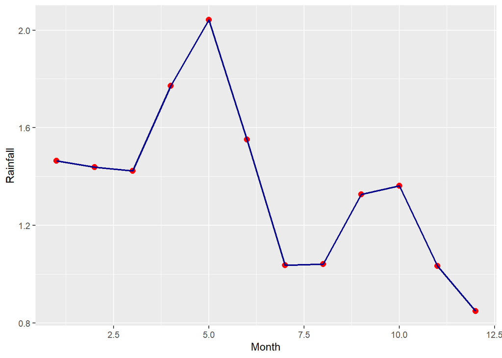

```r
tx=data.frame(forecast_varma$pred)
ggplot(tx, aes(y=Rainfall,x=seq(1,12,by=1)))+
  geom_point(color="red",size=2.5)+
  xlab("Month")+
  geom_line(color="darkblue", size=.75)
```

## 4.Holt-Winter’s Seasonal Method

#### The Holt-Winter’s Seasonal method is used for data with both seasonal patterns and trends. This method can be implemented either by using Additive structure or by using the Multiplicative structure depending on the data set. The Additive structure or model is used when the seasonal pattern of data has the same magnitude or is consistent throughout, while the Multiplicative structure or model is used if the magnitude of the seasonal pattern of the data increases over time. It uses three smoothing parameters,- alpha, beta, and gamma.

### Building model

```r
model4=ets(time_dat, model = "AAA")

summary(model4)
```

```
## ETS(A,A,A)
##
## Call:
##  ets(y = time_dat, model = "AAA")
##
##   Smoothing parameters:
##     alpha = 0.2173
##     beta  = 1e-04
##     gamma = 1e-04
##
##   Initial states:
##     l = 0.4665
##     b = 0.0074
##     s = -0.8059 -0.9998 -0.712 0.4744 -0.5488 1.0573
##            2.2309 -0.6021 -0.3668 -0.4011 -0.3882 1.0622
##
##   sigma:  2.7469
##
##      AIC     AICc      BIC
## 802.6314 808.8763 849.4425
##
## Training set error measures:
##                       ME     RMSE      MAE MPE MAPE    MASE      ACF1
## Training set -0.03117401 2.550454 1.520452 NaN  Inf 1.02732 0.1561261
```

#### After building the model, we get aic and bic values as 802.63 and 849.442 respectively.

### Forecast plot

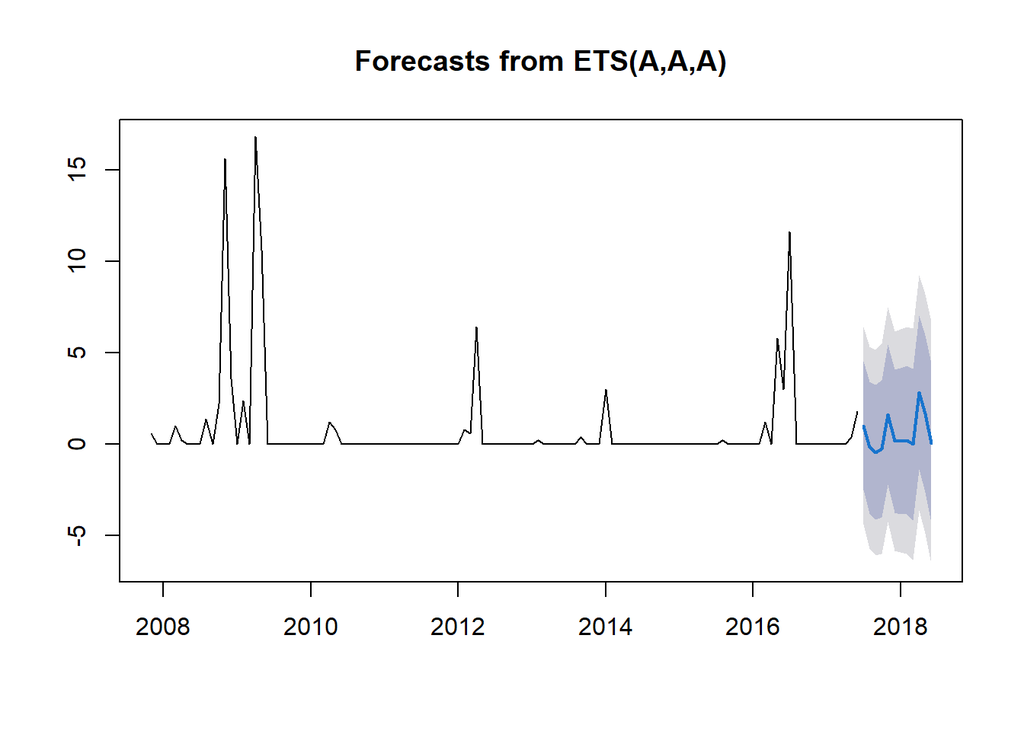

```r
forect3 <- forecast(model4,h = 1*12)
plot(forect3)
```

### Comparing all models on the basis of AIC and BIC

#### Model-1

```r
summary(model1)
```

```
## Series: time_dat
## ARIMA(1,0,0) with non-zero mean
##
## Coefficients:
##          ar1    mean
##       0.3067  0.7941
## s.e.  0.0879  0.3389
##
## sigma^2 estimated as 6.564:  log likelihood=-272.77
## AIC=551.55   AICc=551.76   BIC=559.81
##
## Training set error measures:
##                        ME     RMSE      MAE  MPE MAPE      MASE       ACF1
## Training set 0.0006047933 2.539933 1.156613 -Inf  Inf 0.7814859 0.00766371
```

#### Model-2

```r
summary(model2)
```

```
##
## VAR Estimation Results:
## =========================
## Endogenous variables: Pressure3pm, Rainfall
## Deterministic variables: none
## Sample size: 113
## Log Likelihood: -563.994
## Roots of the characteristic polynomial:
##     1 0.5886 0.5886 0.4332 0.3399 0.1201
## Call:
## vars::VAR(y = ts_data_vars, type = "none", lag.max = 5, ic = "AIC")
##
##
## Estimation results for equation Pressure3pm:
## ============================================
## Pressure3pm = Pressure3pm.l1 + Rainfall.l1 + Pressure3pm.l2 + Rainfall.l2 + Pressure3pm.l3 + Rainfall.l3
##
##                Estimate Std. Error t value Pr(>|t|)
## Pressure3pm.l1  0.97181    0.09609  10.114  < 2e-16 ***
## Rainfall.l1     0.20782    0.14290   1.454  0.14881
## Pressure3pm.l2 -0.24269    0.13155  -1.845  0.06783 .
## Rainfall.l2     0.24756    0.14794   1.673  0.09718 .
## Pressure3pm.l3  0.27064    0.09814   2.758  0.00685 **
## Rainfall.l3    -0.02985    0.14538  -0.205  0.83769
## ---
## Signif. codes:  0 '***' 0.001 '**' 0.01 '*' 0.05 '.' 0.1 ' ' 1
##
##
## Residual standard error: 3.668 on 107 degrees of freedom
## Multiple R-Squared:     1,   Adjusted R-squared:     1
## F-statistic: 1.428e+06 on 6 and 107 DF,  p-value: < 2.2e-16
##
##
## Estimation results for equation Rainfall:
## =========================================
## Rainfall = Pressure3pm.l1 + Rainfall.l1 + Pressure3pm.l2 + Rainfall.l2 + Pressure3pm.l3 + Rainfall.l3
##
##                Estimate Std. Error t value Pr(>|t|)
## Pressure3pm.l1 -0.15487    0.06679  -2.319  0.02232 *
## Rainfall.l1     0.28984    0.09934   2.918  0.00430 **
```

[output cut: 8 more lines]

```
## Residual standard error: 2.55 on 107 degrees of freedom
## Multiple R-Squared: 0.2268,  Adjusted R-squared: 0.1834
## F-statistic:  5.23 on 6 and 107 DF,  p-value: 9.324e-05
##
##
##
## Covariance matrix of residuals:
##             Pressure3pm Rainfall
## Pressure3pm      13.455   -2.178
## Rainfall         -2.178    6.501
##
## Correlation matrix of residuals:
##             Pressure3pm Rainfall
## Pressure3pm      1.0000  -0.2329
## Rainfall        -0.2329   1.0000
```

#### Model-4

```r
summary(model4)
```

```
## ETS(A,A,A)
##
## Call:
##  ets(y = time_dat, model = "AAA")
##
##   Smoothing parameters:
##     alpha = 0.2173
##     beta  = 1e-04
##     gamma = 1e-04
##
##   Initial states:
##     l = 0.4665
##     b = 0.0074
##     s = -0.8059 -0.9998 -0.712 0.4744 -0.5488 1.0573
##            2.2309 -0.6021 -0.3668 -0.4011 -0.3882 1.0622
##
##   sigma:  2.7469
##
##      AIC     AICc      BIC
## 802.6314 808.8763 849.4425
##
## Training set error measures:
##                       ME     RMSE      MAE MPE MAPE    MASE      ACF1
## Training set -0.03117401 2.550454 1.520452 NaN  Inf 1.02732 0.1561261
```

### Inferences:

#### 1. The better model when two models are compared, the one with less AiC and BiC values are better models.

# Classification

## Preprocesssing

### Structure of the data

```r
class_data=data
class_data=class_data[,c(-1,-2,-8,-10,-11,-24)]
str(class_data)
```

```
## 'data.frame':    145460 obs. of  18 variables:
##  $ MinTemp      : num  13.4 7.4 12.9 9.2 17.5 14.6 14.3 7.7 9.7 13.1 ...
##  $ MaxTemp      : num  22.9 25.1 25.7 28 32.3 29.7 25 26.7 31.9 30.1 ...
##  $ Rainfall     : num  0.6 0 0 0 1 0.2 0 0 0 1.4 ...
##  $ Evaporation  : num  5.47 5.47 5.47 5.47 5.47 ...
##  $ Sunshine     : num  7.61 7.61 7.61 7.61 7.61 ...
##  $ WindGustSpeed: num  44 44 46 24 41 56 50 35 80 28 ...
##  $ WindSpeed9am : num  20 4 19 11 7 19 20 6 7 15 ...
##  $ WindSpeed3pm : num  24 22 26 9 20 24 24 17 28 11 ...
##  $ Humidity9am  : num  71 44 38 45 82 55 49 48 42 58 ...
##  $ Humidity3pm  : num  22 25 30 16 33 23 19 19 9 27 ...
##  $ Pressure9am  : num  1008 1011 1008 1018 1011 ...
##  $ Pressure3pm  : num  1007 1008 1009 1013 1006 ...
##  $ Cloud9am     : num  8 4.45 4.45 4.45 7 ...
##  $ Cloud3pm     : num  4.51 4.51 2 4.51 8 ...
##  $ Temp9am      : num  16.9 17.2 21 18.1 17.8 20.6 18.1 16.3 18.3 20.1 ...
##  $ Temp3pm      : num  21.8 24.3 23.2 26.5 29.7 28.9 24.6 25.5 30.2 28.2 ...
##  $ RainToday    : Factor w/ 2 levels "0","1": 1 1 1 1 1 1 1 1 1 2 ...
##  $ RainTomorrow : Factor w/ 2 levels "0","1": 1 1 1 1 1 1 1 1 2 1 ...
```

### Encoding in 0,1

```r
class_data$RainToday=as.numeric(class_data$RainToday)
class_data$RainTomorrow=as.numeric(class_data$RainTomorrow)

class_data=class_data%>%
  mutate(RainToday=replace(RainToday, is.na(RainToday), 2))

class_data=class_data%>%
  mutate(RainTomorrow=replace(RainTomorrow, is.na(RainTomorrow), 2))

class_data$RainToday=ifelse(class_data$RainToday>1,1,0)
class_data$RainTomorrow=ifelse(class_data$RainTomorrow>1,1,0)
```

### Correlation Plot

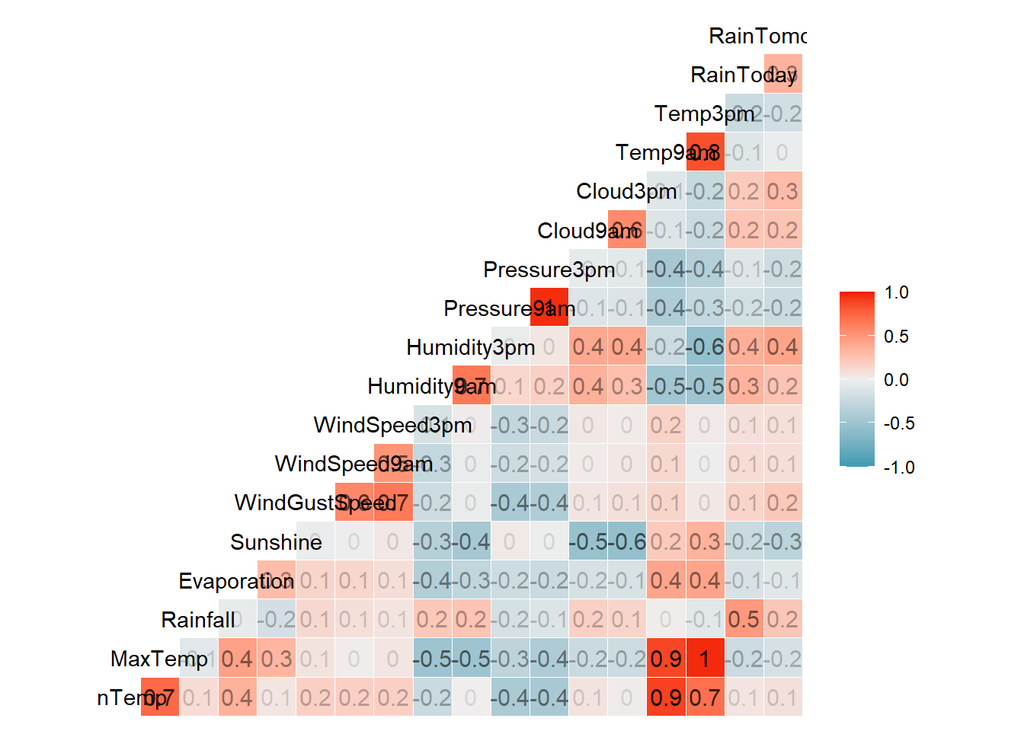

```r
ggcorr(class_data,label=TRUE,label_alpha = TRUE)
```

## 1. Logistic Regression

### Splitting data into training and testing

```r
set.seed(123)
split = sample.split(class_data$RainToday, SplitRatio = 0.8)
train_data = subset(class_data, split == TRUE)
test_data = subset(class_data, split == FALSE)
```

#### Here we are splitting the data into 8:2 ratio.

### Model Building

### Model1

```r
model1 <- glm(RainToday~Humidity3pm+Temp3pm+Pressure3pm,data=train_data,family = "binomial")
summary(model1)$coeff
```

```
##                Estimate   Std. Error   z value     Pr(>|z|)
## (Intercept) 48.82465756 1.2145065650  40.20123  0.00000e+00
## Humidity3pm  0.04078243 0.0004611149  88.44310  0.00000e+00
## Temp3pm     -0.04425208 0.0014031076 -31.53862 2.56843e-218
## Pressure3pm -0.05057693 0.0011826901 -42.76431  0.00000e+00
```

#### Here we can see that Temp3pm is significant(since, p-val<0.05).

### Model2

```r
model2 <- glm(RainToday~Humidity9am+Temp9am+Pressure9am,data=train_data,family = "binomial")
summary(model2)$coeff
```

```
##                 Estimate   Std. Error   z value  Pr(>|z|)
## (Intercept) 79.689942686 1.2604098834  63.22542 0.0000000
## Humidity9am  0.060083299 0.0005605483 107.18665 0.0000000
## Temp9am      0.002929732 0.0013724842   2.13462 0.0327921
## Pressure9am -0.083853311 0.0012333707 -67.98711 0.0000000
```

#### Here we can see that Temp9am is significant(since, p-val<0.05).

### Model3

```r
model3 <- glm(RainToday~.-Rainfall-RainTomorrow,data=train_data,family = "binomial")
summary(model3)$coeff
```

```
##                   Estimate   Std. Error    z value      Pr(>|z|)
## (Intercept)   38.419693041 1.4688861187  26.155665 8.496321e-151
## MinTemp        0.125641346 0.0041786592  30.067383 1.294016e-198
## MaxTemp       -0.171433741 0.0053424283 -32.089105 6.256558e-226
## Evaporation   -0.081797293 0.0039697176 -20.605318  2.458999e-94
## Sunshine       0.010591375 0.0038831785   2.727502  6.381595e-03
## WindGustSpeed  0.026688095 0.0009153084  29.157491 6.713406e-187
## WindSpeed9am   0.017866448 0.0012387398  14.423084  3.704130e-47
## WindSpeed3pm  -0.020111073 0.0012869986 -15.626336  4.817169e-55
## Humidity9am    0.059614995 0.0008928436  66.769809  0.000000e+00
## Humidity3pm   -0.005759873 0.0008639659  -6.666782  2.614723e-11
## Pressure9am   -0.206066345 0.0048485608 -42.500518  0.000000e+00
## Pressure3pm    0.163669193 0.0048212945  33.947147 1.343917e-252
## Cloud9am       0.019989318 0.0048406194   4.129496  3.635596e-05
## Cloud3pm       0.028937830 0.0052451046   5.517112  3.446158e-08
## Temp9am        0.065363468 0.0056923831  11.482619  1.613181e-30
## Temp3pm        0.006307112 0.0056981723   1.106866  2.683519e-01
```

### Predicting the output and getting the accuracy

### Model1

```r
proba <- model1 %>%
  predict(test_data,type="response")
head(proba)
```

```
##          4          5          8         15         19         23
## 0.05118248 0.11668525 0.06807374 0.12706318 0.13387468 0.08130494
```

#### Class Prediction

```r
pred_class <- ifelse(proba<0.5,0,1)
head(pred_class)
```

```
##  4  5  8 15 19 23
##  0  0  0  0  0  0
```

### Confusion Matrix for model1

```r
table(test_data$RainToday,pred_class)
```

```
##    pred_class
##         0     1
##   0 20811  1253
##   1  5355  1673
```

### Accuracy

```r
mean(pred_class==test_data$RainToday)
```

```
## [1] 0.7728585
```

#### The accuracy of model-1 is 77.28%

### Model2

```r
proba <- model2 %>%
  predict(test_data,type="response")
head(proba)
```

```
##          4          5          8         15         19         23
## 0.05302997 0.47751405 0.08664939 0.18161931 0.11083268 0.18194896
```

#### Class Prediction

```r
pred_class <- ifelse(proba<0.5,0,1)
head(pred_class)
```

```
##  4  5  8 15 19 23
##  0  0  0  0  0  0
```

### Accuracy

```r
mean(pred_class==test_data$RainToday)
```

```
## [1] 0.7876048
```

```r
table(test_data$RainToday,pred_class)
```

```
##    pred_class
##         0     1
##   0 20750  1314
##   1  4865  2163
```

### Model3

```r
proba <- model3 %>%
  predict(test_data,type="response")
head(proba)
```

```
##           4           5           8          15          19          23
## 0.008977724 0.155961016 0.015291257 0.050994567 0.119287176 0.140307665
```

#### Class Prediction

```r
pred_class <- ifelse(proba<0.5,0,1)
head(pred_class)
```

```
##  4  5  8 15 19 23
##  0  0  0  0  0  0
```

### Confusion Matrix for model3

```r
table(test_data$RainToday,pred_class)
```

```
##    pred_class
##         0     1
##   0 20550  1514
##   1  3892  3136
```